# MoneyPuck

A Statistical Examination of Player Quality in the NHL

Dan Savickas

5/2/2017

[figure not shown]

## Abstract

If any professional sports league draws little or no attention to contract details, it is the NHL. The league receives paltry coverage in the media and is generally regarded as the least popular of the major sports in the United States. Thus, poorly drawn up contracts, grossly overpaid and underpaid players, and dark horses generally fly under the radar to the casual fan. However, even a brief analysis of the data suggests that there is a significant discrepancy between the players that produce wins for their team, and those that are the most highly paid. Of course, there is the unquantifiable star power factor to consider, but for the purposes of winning games, NHL front offices appear to be off-base. In the spirit of the sabermetrics that revolutionized the MLB, and produced the Oscar-nominated picture, “MoneyBall”, this inquiry is an effort to develop an algorithm that more accurately reflects player value, than any existing metric. This metric is based off of data from the 2016-17 NHL Season.

## Acknowledgements

Special thanks are owed to Professor Sean Carver, PhD, of American University, for providing guidance and his own knowledge of RStudio, which greatly contributed to this final product. Also providing invaluable assistance in this inquiry was Paul Jeffries, an American University student, and financial engineer at Fannie Mae. Statistics referenced were pulled from hockey-reference .com and salary data from sportrac. com.

## Definitions

For this data, a Goalie was defined as an NHL Goaltender who started at least 12 games in the 2016-17 season. Likewise, a Skater was defined as a Forward or Defenseman who played in at least one-fifth (16) of his team’s games in the 2016-17 season. This data, these tests, and the value estimations for these players only reflect that of the 2016-17 season.

## Statistical Testing

Given that, in the NHL, different teams have various schemes, gameplans, line changes, and strategies in play, the most direct possible comparisons of player value come at the Goaltender position. A goalie is either going to allow a shot to go in, or he isn’t. Of course, being an NHL goaltender is much harder work than that simplification, but that is the essence of a goaltender’s duties. The relevant statistics considered to be expected to contribute to a goalie’s salary were Age, Win Percentage, Save Percentage, Goals Against per Game, Saves Per Game, Shutout Percentage, and Quality Start Percentage (A quality start is a game in which a goalie has a save percentage higher than the league average, or one in which he saves 88.5% of shots, while also allowing fewer than 2 goals). Knowing logically that Save Percentage, Saves Per Game, and Goals Against Average would be cross-correlated, three separate multiple regressions were run.

## Goalie Salary Regression Tests

As is evident by the data, the only metrics that ended up correlating with a Goalie’s salary were Age and Games Started. No other hockey statistic registered as significant. Win%, GAA, SV%, SVPG, and QS% all produced fairly large p-values. Results are shown below.

### Save Percentage

```
Call:
lm(formula = NHL_Goalies$Salary[Goalies] ~ NHL_Goalies$Age[Goalies] +
    NHL_Goalies$GS[Goalies] + NHL_Goalies$WinPerc[Goalies] +
    NHL_Goalies$`SV%`[Goalies] + NHL_Goalies$SOPerc[Goalies] +
    NHL_Goalies$`QS%`[Goalies])

Residuals:
    Min      1Q  Median      3Q     Max
-5.1260 -1.1892 -0.2215  0.8544  4.2820

Coefficients:
                              Estimate Std. Error t value Pr(>|t|)
(Intercept)                  -30.85565   38.04793  -0.811 0.421011
NHL_Goalies$Age[Goalies]       0.32377    0.06821   4.746 1.61e-05 ***
NHL_Goalies$GS[Goalies]        0.05990    0.01463   4.094 0.000146 ***
NHL_Goalies$WinPerc[Goalies]  -1.81413    3.26325  -0.556 0.580599
NHL_Goalies$`SV%`[Goalies]    26.04093   43.65053   0.597 0.553329
NHL_Goalies$SOPerc[Goalies]   -4.78837    6.45051  -0.742 0.461169
NHL_Goalies$`QS%`[Goalies]     0.08664    4.67038   0.019 0.985269
---
Signif. codes:  0 '***' 0.001 '**' 0.01 '*' 0.05 '.' 0.1 ' ' 1

Residual standard error: 1.888 on 53 degrees of freedom
Multiple R-squared:  0.502, Adjusted R-squared:  0.4457
F-statistic: 8.906 on 6 and 53 DF,  p-value: 1.004e-06
```

### Goals Against Average

```
Call:
lm(formula = NHL_Goalies$Salary[Goalies] ~ NHL_Goalies$Age[Goalies] +
    NHL_Goalies$GS[Goalies] + NHL_Goalies$WinPerc[Goalies] +
    NHL_Goalies$GAA[Goalies] + NHL_Goalies$SOPerc[Goalies] +
    NHL_Goalies$`QS%`[Goalies])

Residuals:
    Min      1Q  Median      3Q     Max
-5.1642 -1.1042 -0.2073  0.8998  4.2657

Coefficients:
                             Estimate Std. Error t value Pr(>|t|)
(Intercept)                  -8.71021    6.51359  -1.337    0.187
NHL_Goalies$Age[Goalies]      0.31781    0.06774   4.691 1.95e-05 ***
NHL_Goalies$GS[Goalies]       0.06201    0.01465   4.232 9.23e-05 ***
NHL_Goalies$WinPerc[Goalies] -1.17768    3.61302  -0.326    0.746
NHL_Goalies$GAA[Goalies]      0.11718    1.39669   0.084    0.933
NHL_Goalies$SOPerc[Goalies]  -4.63292    6.55639  -0.707    0.483
NHL_Goalies$`QS%`[Goalies]    2.12154    4.39130   0.483    0.631
---
Signif. codes:  0 '***' 0.001 '**' 0.01 '*' 0.05 '.' 0.1 ' ' 1

Residual standard error: 1.895 on 53 degrees of freedom
Multiple R-squared:  0.4988,    Adjusted R-squared:  0.442
F-statistic:  8.79 on 6 and 53 DF,  p-value: 1.18e-06
```

### Saves Per Game

```
Call:
lm(formula = NHL_Goalies$Salary[Goalies] ~ NHL_Goalies$Age[Goalies] +
    NHL_Goalies$GS[Goalies] + NHL_Goalies$WinPerc[Goalies] +
    NHL_Goalies$SVPG[Goalies] + NHL_Goalies$SOPerc[Goalies] +
    NHL_Goalies$`QS%`[Goalies])

Residuals:
    Min      1Q  Median      3Q     Max
-4.8796 -1.1307 -0.0663  0.8622  4.4509

Coefficients:
                              Estimate Std. Error t value Pr(>|t|)
(Intercept)                  -10.33195    3.69967  -2.793 0.007256 **
NHL_Goalies$Age[Goalies]       0.32229    0.06761   4.767  1.5e-05 ***
NHL_Goalies$GS[Goalies]        0.05866    0.01483   3.955 0.000229 ***
NHL_Goalies$WinPerc[Goalies]  -0.70869    3.25275  -0.218 0.828365
NHL_Goalies$SVPG[Goalies]      0.08273    0.10852   0.762 0.449256
NHL_Goalies$SOPerc[Goalies]   -3.88732    6.52835  -0.595 0.554075
NHL_Goalies$`QS%`[Goalies]     1.24446    3.63624   0.342 0.733525
---
Signif. codes:  0 '***' 0.001 '**' 0.01 '*' 0.05 '.' 0.1 ' ' 1

Residual standard error: 1.884 on 53 degrees of freedom
Multiple R-squared:  0.5041,    Adjusted R-squared:  0.448
F-statistic: 8.981 on 6 and 53 DF,  p-value: 9.045e-07
```

## Goalie Win% Regression Tests

To test whether this is a reasonable, or effective, way to pay Goalies, a round of multiple regressions was run with Win Percentage as the dependent variable. This is to see if any hockey statistic can be statistically shown to have a significant correlation with wins. It will also show whether or not the significance levels were comparable to those for the salary regressions. Each statistic registered different significance levels. GAA had a p-value of about .0001, meaning there was just about a 99.99% chance that that statistic is significant for wins. SV% and SO% (in one of three tests) also registered statistically significant results. Full results are shown below.

### Save Percentage

```
Call:
lm(formula = NHL_Goalies$WinPerc[Goalies] ~ NHL_Goalies$Age[Goalies] +
    NHL_Goalies$`SV%`[Goalies] + NHL_Goalies$SOPerc[Goalies] +
    NHL_Goalies$`QS%`[Goalies])

Residuals:
     Min       1Q   Median       3Q      Max
-0.16032 -0.04795  0.01205  0.05514  0.12193

Coefficients:
                             Estimate Std. Error t value Pr(>|t|)
(Intercept)                 -2.849095   1.490201  -1.912   0.0611 .
NHL_Goalies$Age[Goalies]    -0.002166   0.002760  -0.785   0.4359
NHL_Goalies$`SV%`[Goalies]   3.555366   1.699088   2.093   0.0410 *
NHL_Goalies$SOPerc[Goalies]  0.544368   0.256176   2.125   0.0381 *
NHL_Goalies$`QS%`[Goalies]   0.239639   0.189628   1.264   0.2117
---
Signif. codes:  0 '***' 0.001 '**' 0.01 '*' 0.05 '.' 0.1 ' ' 1

Residual standard error: 0.07817 on 55 degrees of freedom
Multiple R-squared:  0.4327,    Adjusted R-squared:  0.3914
F-statistic: 10.49 on 4 and 55 DF,  p-value: 2.192e-06
```

### Goals Against Average

```
Call:
lm(formula = NHL_Goalies$WinPerc[Goalies] ~ NHL_Goalies$Age[Goalies] +
    NHL_Goalies$GAA[Goalies] + NHL_Goalies$SOPerc[Goalies] +
    NHL_Goalies$`QS%`[Goalies])

Residuals:
      Min        1Q    Median        3Q       Max
-0.168580 -0.042998  0.002643  0.041368  0.129589

Coefficients:
                             Estimate Std. Error t value Pr(>|t|)
(Intercept)                  1.004503   0.196581   5.110 4.18e-06 ***
NHL_Goalies$Age[Goalies]    -0.002384   0.002475  -0.963 0.339720
NHL_Goalies$GAA[Goalies]    -0.186200   0.044419  -4.192 0.000101 ***
NHL_Goalies$SOPerc[Goalies]  0.317316   0.239870   1.323 0.191353
NHL_Goalies$`QS%`[Goalies]   0.052197   0.163228   0.320 0.750348
---
Signif. codes:  0 '***' 0.001 '**' 0.01 '*' 0.05 '.' 0.1 ' ' 1

Residual standard error: 0.0707 on 55 degrees of freedom
Multiple R-squared:  0.5358,    Adjusted R-squared:  0.5021
F-statistic: 15.87 on 4 and 55 DF,  p-value: 1.074e-08
```

### Saves Per Game

```
Call:
lm(formula = NHL_Goalies$WinPerc[Goalies] ~ NHL_Goalies$Age[Goalies] +
    NHL_Goalies$SVPG[Goalies] + NHL_Goalies$SOPerc[Goalies] +
    NHL_Goalies$`QS%`[Goalies])

Residuals:
      Min        1Q    Median        3Q       Max
-0.181978 -0.047541  0.003387  0.058399  0.153384

Coefficients:
                             Estimate Std. Error t value Pr(>|t|)
(Intercept)                  0.427356   0.141177   3.027  0.00375 **
NHL_Goalies$Age[Goalies]    -0.003031   0.002775  -1.092  0.27950
NHL_Goalies$SVPG[Goalies]   -0.006848   0.004300  -1.593  0.11699
NHL_Goalies$SOPerc[Goalies]  0.487890   0.267112   1.827  0.07320 .
NHL_Goalies$`QS%`[Goalies]   0.564920   0.132939   4.249 8.35e-05 ***
---
Signif. codes:  0 '***' 0.001 '**' 0.01 '*' 0.05 '.' 0.1 ' ' 1

Residual standard error: 0.07941 on 55 degrees of freedom
Multiple R-squared:  0.4145,    Adjusted R-squared:  0.3719
F-statistic: 9.735 on 4 and 55 DF,  p-value: 5.014e-06
```

## The Jeffrickas Index

Some of the above results were striking, as GAA, SV%, and SO% registered significantly for Win%, but did not register as significant for salary data. This was a common finding, indicating that contribution to wins on the ice did not necessarily translate into a higher salary from the front office. The results from the Win% regressions led to the creation of an algorithm that could serve as an index to model how efficiently a Goalie contributes to his team winning. This model was generated by multiplying the z-score for each statistic (no. of standard deviations above the league average) by the square of the average t-value for that same statistic (while maintaining the positive or negative nature of the correlation). That number was then adjusted to produce an average score of zero across the index.

This index was named the “Jeffrickas Index” to combine my last name, with that of Paul Jeffries, whose contributions helped establish this inquiry. It is important to note that this Jeffrickas score indicates value not over the course of a Goalie’s entire career or of multiple seasons, but for only the 2016-17 season.

Here are the summary statistics of that index for Goalies:

```
   Min. 1st Qu.  Median    Mean 3rd Qu.    Max.
-6.3880 -2.4520 -0.5601  0.0000  2.2410  7.8290
```

When plotted, you can see that there is a definite positive correlation between a Goalie’s Jeffrickas score, and win percentage. The Jeffrickas Index for Goalies correlated 73.33% with win percentage, making it more predictive than any one statistic (the next closest was GAA, which correlated slightly above 71%).

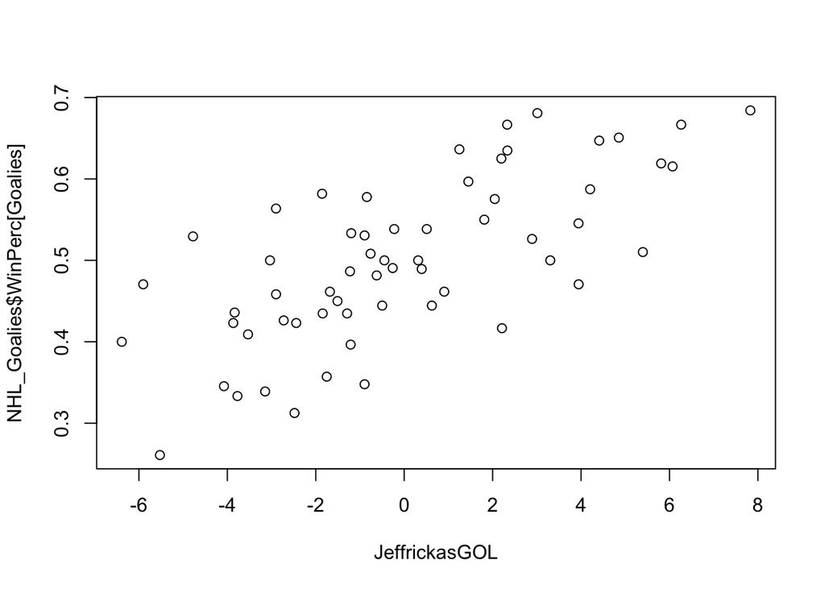

## Forward Salary Regression Tests

Having established an index for Goalies, and a general understanding of what statistics contribute to both salary and Win%, the same methodology was then applied to Skaters (non-goalies). However, due to the differing roles each position plays on the ice, the Skaters were divided into Forwards and Defensemen, each getting their own regression model and Jeffrickas Index.

For Skaters, Shots (S) and Goals (G) were found to be cross-correlated, as it stands to reason that a player who takes more shots will score more goals. As such, two separate regressions were run to account for said cross correlation.

### Shots

```
Call:
lm(formula = NHL_Skaters$Salary[Forward] ~ NHL_Skaters$Age[Forward] +
    NHL_Skaters$GP[Forward] + NHL_Skaters$SPG[Forward] + NHL_Skaters$APG[Forward] +
    NHL_Skaters$PenPG[Forward] + NHL_Skaters$`S%`[Forward] +
    NHL_Skaters$ATOI[Forward] + NHL_Skaters$BPG[Forward] + NHL_Skaters$HPG[Forward] +
    NHL_Skaters$PlusMinusAdj[Forward])

Residuals:
    Min      1Q  Median      3Q     Max
-5.0263 -0.8112 -0.0450  0.8194  4.7567

Coefficients:
                                   Estimate Std. Error t value Pr(>|t|)
(Intercept)                       -8.491831   0.574160 -14.790  < 2e-16
NHL_Skaters$Age[Forward]           0.192248   0.015923  12.073  < 2e-16
NHL_Skaters$GP[Forward]           -0.012680   0.004725  -2.684 0.007563
NHL_Skaters$SPG[Forward]           0.658730   0.159804   4.122 4.51e-05
NHL_Skaters$APG[Forward]           2.872683   0.806467   3.562 0.000409
NHL_Skaters$PenPG[Forward]         0.102170   0.216049   0.473 0.636522
NHL_Skaters$`S%`[Forward]         -0.026872   0.018967  -1.417 0.157271
NHL_Skaters$ATOI[Forward]          0.326666   0.049279   6.629 1.02e-10
NHL_Skaters$BPG[Forward]          -0.072321   0.370345  -0.195 0.845267
NHL_Skaters$HPG[Forward]           0.345894   0.117586   2.942 0.003442
NHL_Skaters$PlusMinusAdj[Forward] -0.015328   0.009271  -1.653 0.098998

(Intercept)                       ***
NHL_Skaters$Age[Forward]          ***
NHL_Skaters$GP[Forward]           **
NHL_Skaters$SPG[Forward]          ***
NHL_Skaters$APG[Forward]          ***
NHL_Skaters$PenPG[Forward]
NHL_Skaters$`S%`[Forward]
NHL_Skaters$ATOI[Forward]         ***
NHL_Skaters$BPG[Forward]
NHL_Skaters$HPG[Forward]          **
NHL_Skaters$PlusMinusAdj[Forward] .
---
Signif. codes:  0 '***' 0.001 '**' 0.01 '*' 0.05 '.' 0.1 ' ' 1

Residual standard error: 1.444 on 429 degrees of freedom
Multiple R-squared:  0.6156,    Adjusted R-squared:  0.6067
F-statistic: 68.71 on 10 and 429 DF,  p-value: < 2.2e-16
```

### Goals

```
Call:
lm(formula = NHL_Skaters$Salary[Forward] ~ NHL_Skaters$Age[Forward] +
    NHL_Skaters$GP[Forward] + NHL_Skaters$GPG[Forward] + NHL_Skaters$APG[Forward] +
    NHL_Skaters$PenPG[Forward] + NHL_Skaters$`S%`[Forward] +
    NHL_Skaters$ATOI[Forward] + NHL_Skaters$BPG[Forward] + NHL_Skaters$HPG[Forward] +
    NHL_Skaters$PlusMinusAdj[Forward])

Residuals:
    Min      1Q  Median      3Q     Max
-4.7789 -0.7942 -0.0637  0.8269  4.8119

Coefficients:
                                   Estimate Std. Error t value Pr(>|t|)
(Intercept)                       -7.887608   0.610234 -12.926  < 2e-16
NHL_Skaters$Age[Forward]           0.190864   0.016002  11.928  < 2e-16
NHL_Skaters$GP[Forward]           -0.011713   0.004738  -2.472 0.013809
NHL_Skaters$GPG[Forward]           4.528575   1.291434   3.507 0.000502
NHL_Skaters$APG[Forward]           2.857403   0.813830   3.511 0.000494
NHL_Skaters$PenPG[Forward]         0.048048   0.217599   0.221 0.825345
NHL_Skaters$`S%`[Forward]         -0.096862   0.025691  -3.770 0.000186
NHL_Skaters$ATOI[Forward]          0.358104   0.047338   7.565 2.39e-13
NHL_Skaters$BPG[Forward]          -0.182972   0.368682  -0.496 0.619946
NHL_Skaters$HPG[Forward]           0.356645   0.118102   3.020 0.002680
NHL_Skaters$PlusMinusAdj[Forward] -0.016852   0.009342  -1.804 0.071952

(Intercept)                       ***
NHL_Skaters$Age[Forward]          ***
NHL_Skaters$GP[Forward]           *
NHL_Skaters$GPG[Forward]          ***
NHL_Skaters$APG[Forward]          ***
NHL_Skaters$PenPG[Forward]
NHL_Skaters$`S%`[Forward]         ***
NHL_Skaters$ATOI[Forward]         ***
NHL_Skaters$BPG[Forward]
NHL_Skaters$HPG[Forward]          **
NHL_Skaters$PlusMinusAdj[Forward] .
---
Signif. codes:  0 '***' 0.001 '**' 0.01 '*' 0.05 '.' 0.1 ' ' 1

Residual standard error: 1.452 on 429 degrees of freedom
Multiple R-squared:  0.6115,    Adjusted R-squared:  0.6025
F-statistic: 67.53 on 10 and 429 DF,  p-value: < 2.2e-16
```

## Forward Team Pts Regression Test

### Shots

```
Call:
lm(formula = NHL_Skaters$TmPoints[Forward] ~ NHL_Skaters$Age[Forward] +
    NHL_Skaters$GP[Forward] + NHL_Skaters$APG[Forward] + NHL_Skaters$PenPG[Forward] +
    NHL_Skaters$SPG[Forward] + NHL_Skaters$`S%`[Forward] + NHL_Skaters$ATOI[Forward] +
    NHL_Skaters$BPG[Forward] + NHL_Skaters$HPG[Forward] + NHL_Skaters$PlusMinusAdj[Forward])

Residuals:
    Min      1Q  Median      3Q     Max
-38.915  -8.114   1.142   9.595  30.150

Coefficients:
                                  Estimate Std. Error t value Pr(>|t|)
(Intercept)                       99.54656    5.08861  19.563  < 2e-16 ***
NHL_Skaters$Age[Forward]           0.16153    0.14112   1.145  0.25301
NHL_Skaters$GP[Forward]            0.06881    0.04188   1.643  0.10106
NHL_Skaters$APG[Forward]          50.35183    7.14747   7.045 7.44e-12 ***
NHL_Skaters$PenPG[Forward]        -3.02678    1.91477  -1.581  0.11467
NHL_Skaters$SPG[Forward]           4.05552    1.41630   2.863  0.00440 **
NHL_Skaters$`S%`[Forward]          0.95034    0.16810   5.653 2.87e-08 ***
NHL_Skaters$ATOI[Forward]         -3.58261    0.43674  -8.203 2.75e-15 ***
NHL_Skaters$BPG[Forward]          12.61205    3.28226   3.842  0.00014 ***
NHL_Skaters$HPG[Forward]           1.79195    1.04213   1.720  0.08624 .
NHL_Skaters$PlusMinusAdj[Forward]  0.12124    0.08217   1.476  0.14080
---
Signif. codes:  0 '***' 0.001 '**' 0.01 '*' 0.05 '.' 0.1 ' ' 1

Residual standard error: 12.8 on 429 degrees of freedom
Multiple R-squared:  0.2203,    Adjusted R-squared:  0.2022
F-statistic: 12.12 on 10 and 429 DF,  p-value: < 2.2e-16
```

### Goals

```
Call:
lm(formula = NHL_Skaters$TmPoints[Forward] ~ NHL_Skaters$Age[Forward] +
    NHL_Skaters$GP[Forward] + NHL_Skaters$APG[Forward] + NHL_Skaters$PenPG[Forward] +
    NHL_Skaters$GPG[Forward] + NHL_Skaters$`S%`[Forward] + NHL_Skaters$ATOI[Forward] +
    NHL_Skaters$BPG[Forward] + NHL_Skaters$HPG[Forward] + NHL_Skaters$PlusMinusAdj[Forward])

Residuals:
    Min      1Q  Median      3Q     Max
-38.920  -8.294   1.275   9.653  30.141

Coefficients:
                                   Estimate Std. Error t value Pr(>|t|)
(Intercept)                       104.27661    5.37386  19.404  < 2e-16
NHL_Skaters$Age[Forward]            0.16311    0.14092   1.157 0.247716
NHL_Skaters$GP[Forward]             0.07390    0.04172   1.771 0.077239
NHL_Skaters$APG[Forward]           49.62244    7.16677   6.924 1.61e-11
NHL_Skaters$PenPG[Forward]         -3.42775    1.91623  -1.789 0.074353
NHL_Skaters$GPG[Forward]           34.42311   11.37267   3.027 0.002620
NHL_Skaters$`S%`[Forward]           0.43149    0.22624   1.907 0.057163
NHL_Skaters$ATOI[Forward]          -3.48973    0.41687  -8.371 8.15e-16
NHL_Skaters$BPG[Forward]           12.31934    3.24670   3.794 0.000169
NHL_Skaters$HPG[Forward]            1.81981    1.04003   1.750 0.080875
NHL_Skaters$PlusMinusAdj[Forward]   0.10848    0.08227   1.319 0.187999

(Intercept)                       ***
NHL_Skaters$Age[Forward]
NHL_Skaters$GP[Forward]           .
NHL_Skaters$APG[Forward]          ***
NHL_Skaters$PenPG[Forward]        .
NHL_Skaters$GPG[Forward]          **
NHL_Skaters$`S%`[Forward]         .
NHL_Skaters$ATOI[Forward]         ***
NHL_Skaters$BPG[Forward]          ***
NHL_Skaters$HPG[Forward]          .
NHL_Skaters$PlusMinusAdj[Forward]
---
Signif. codes:  0 '***' 0.001 '**' 0.01 '*' 0.05 '.' 0.1 ' ' 1

Residual standard error: 12.79 on 429 degrees of freedom
Multiple R-squared:  0.222, Adjusted R-squared:  0.2039
F-statistic: 12.24 on 10 and 429 DF,  p-value: < 2.2e-16
```

## Forward Jeffrickas Index

Again, it is important to note that this only reflects value compared to salary for this season, and not over the course of multiple seasons.

The summary statistics for Forwards’ Jeffrickas and the graph of its correlation with Team Points are shown below.

```
   Min. 1st Qu.  Median    Mean 3rd Qu.    Max.
-30.170 -10.530  -1.516   0.000  10.390  38.740
```

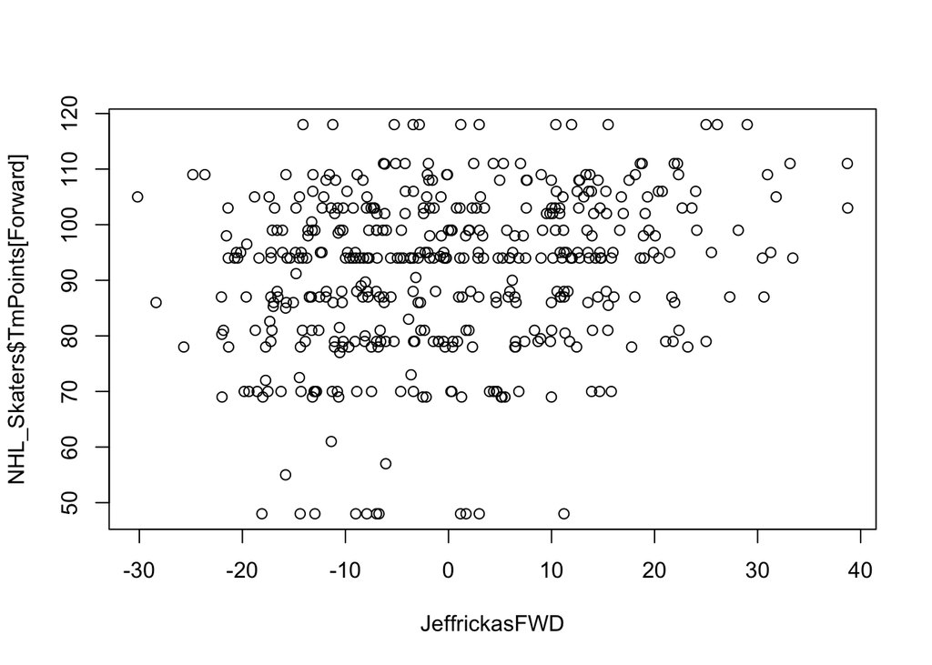

## Defender Salary Regression Tests

### Shots

```
Call:
lm(formula = NHL_Skaters$Salary[Defender] ~ NHL_Skaters$Age[Defender] +
    NHL_Skaters$GP[Defender] + NHL_Skaters$SPG[Defender] + NHL_Skaters$APG[Defender] +
    NHL_Skaters$PenPG[Defender] + NHL_Skaters$`S%`[Defender] +
    NHL_Skaters$ATOI[Defender] + NHL_Skaters$BPG[Defender] +
    NHL_Skaters$HPG[Defender] + NHL_Skaters$PlusMinusAdj[Defender])

Residuals:
    Min      1Q  Median      3Q     Max
-3.1401 -0.8023 -0.0334  0.8349  4.0228

Coefficients:
                                    Estimate Std. Error t value Pr(>|t|)
(Intercept)                        -9.461954   0.697483 -13.566  < 2e-16
NHL_Skaters$Age[Defender]           0.192675   0.020513   9.393  < 2e-16
NHL_Skaters$GP[Defender]           -0.005009   0.005579  -0.898   0.3703
NHL_Skaters$SPG[Defender]           0.384458   0.219282   1.753   0.0809
NHL_Skaters$APG[Defender]           1.140857   0.950254   1.201   0.2312
NHL_Skaters$PenPG[Defender]        -0.025635   0.311177  -0.082   0.9344
NHL_Skaters$`S%`[Defender]         -0.019140   0.030188  -0.634   0.5267
NHL_Skaters$ATOI[Defender]          0.327996   0.045394   7.226 7.75e-12
NHL_Skaters$BPG[Defender]           0.163182   0.215854   0.756   0.4505
NHL_Skaters$HPG[Defender]           0.076222   0.136610   0.558   0.5774
NHL_Skaters$PlusMinusAdj[Defender] -0.015219   0.008783  -1.733   0.0845

(Intercept)                        ***
NHL_Skaters$Age[Defender]          ***
NHL_Skaters$GP[Defender]
NHL_Skaters$SPG[Defender]          .
NHL_Skaters$APG[Defender]
NHL_Skaters$PenPG[Defender]
NHL_Skaters$`S%`[Defender]
NHL_Skaters$ATOI[Defender]         ***
NHL_Skaters$BPG[Defender]
NHL_Skaters$HPG[Defender]
NHL_Skaters$PlusMinusAdj[Defender] .
---
Signif. codes:  0 '***' 0.001 '**' 0.01 '*' 0.05 '.' 0.1 ' ' 1

Residual standard error: 1.236 on 224 degrees of freedom
Multiple R-squared:  0.6536,    Adjusted R-squared:  0.6381
F-statistic: 42.26 on 10 and 224 DF,  p-value: < 2.2e-16
```

### Goals

```
Call:
lm(formula = NHL_Skaters$Salary[Defender] ~ NHL_Skaters$Age[Defender] +
    NHL_Skaters$GP[Defender] + NHL_Skaters$GPG[Defender] + NHL_Skaters$APG[Defender] +
    NHL_Skaters$PenPG[Defender] + NHL_Skaters$`S%`[Defender] +
    NHL_Skaters$ATOI[Defender] + NHL_Skaters$BPG[Defender] +
    NHL_Skaters$HPG[Defender] + NHL_Skaters$PlusMinusAdj[Defender])

Residuals:
    Min      1Q  Median      3Q     Max
-3.1097 -0.7944 -0.0100  0.7949  3.9010

Coefficients:
                                    Estimate Std. Error t value Pr(>|t|)
(Intercept)                        -8.917205   0.716243 -12.450  < 2e-16
NHL_Skaters$Age[Defender]           0.192221   0.020107   9.560  < 2e-16
NHL_Skaters$GP[Defender]           -0.004883   0.005540  -0.882   0.3790
NHL_Skaters$GPG[Defender]           8.089992   3.248114   2.491   0.0135
NHL_Skaters$APG[Defender]           0.982251   0.922702   1.065   0.2882
NHL_Skaters$PenPG[Defender]        -0.083301   0.309884  -0.269   0.7883
NHL_Skaters$`S%`[Defender]         -0.112578   0.047329  -2.379   0.0182
NHL_Skaters$ATOI[Defender]          0.323360   0.043769   7.388 2.92e-12
NHL_Skaters$BPG[Defender]           0.177502   0.213859   0.830   0.4074
NHL_Skaters$HPG[Defender]           0.090756   0.135633   0.669   0.5041
NHL_Skaters$PlusMinusAdj[Defender] -0.017054   0.008730  -1.953   0.0520

(Intercept)                        ***
NHL_Skaters$Age[Defender]          ***
NHL_Skaters$GP[Defender]
NHL_Skaters$GPG[Defender]          *
NHL_Skaters$APG[Defender]
NHL_Skaters$PenPG[Defender]
NHL_Skaters$`S%`[Defender]         *
NHL_Skaters$ATOI[Defender]         ***
NHL_Skaters$BPG[Defender]
NHL_Skaters$HPG[Defender]
NHL_Skaters$PlusMinusAdj[Defender] .
---
Signif. codes:  0 '***' 0.001 '**' 0.01 '*' 0.05 '.' 0.1 ' ' 1

Residual standard error: 1.228 on 224 degrees of freedom
Multiple R-squared:  0.6583,    Adjusted R-squared:  0.643
F-statistic: 43.15 on 10 and 224 DF,  p-value: < 2.2e-16
```

### Shots

```
Call:
lm(formula = NHL_Skaters$TmPoints[Defender] ~ NHL_Skaters$Age[Defender] +
    NHL_Skaters$GP[Defender] + NHL_Skaters$SPG[Defender] + NHL_Skaters$APG[Defender] +
    NHL_Skaters$PenPG[Defender] + NHL_Skaters$`S%`[Defender] +
    NHL_Skaters$ATOI[Defender] + NHL_Skaters$BPG[Defender] +
    NHL_Skaters$HPG[Defender] + NHL_Skaters$PlusMinusAdj[Defender])

Residuals:
    Min      1Q  Median      3Q     Max
-44.604  -9.574   1.466   9.865  27.274

Coefficients:
                                   Estimate Std. Error t value Pr(>|t|)
(Intercept)                        95.92907    7.89683  12.148  < 2e-16
NHL_Skaters$Age[Defender]           0.15800    0.23225   0.680  0.49701
NHL_Skaters$GP[Defender]            0.09516    0.06316   1.507  0.13332
NHL_Skaters$SPG[Defender]           1.11221    2.48269   0.448  0.65460
NHL_Skaters$APG[Defender]          30.29957   10.75869   2.816  0.00529
NHL_Skaters$PenPG[Defender]        -2.81450    3.52311  -0.799  0.42521
NHL_Skaters$`S%`[Defender]          0.75250    0.34179   2.202  0.02871
NHL_Skaters$ATOI[Defender]         -1.63292    0.51395  -3.177  0.00170
NHL_Skaters$BPG[Defender]           3.79311    2.44388   1.552  0.12205
NHL_Skaters$HPG[Defender]           0.10681    1.54668   0.069  0.94501
NHL_Skaters$PlusMinusAdj[Defender]  0.29091    0.09944   2.925  0.00379

(Intercept)                        ***
NHL_Skaters$Age[Defender]
NHL_Skaters$GP[Defender]
NHL_Skaters$SPG[Defender]
NHL_Skaters$APG[Defender]          **
NHL_Skaters$PenPG[Defender]
NHL_Skaters$`S%`[Defender]         *
NHL_Skaters$ATOI[Defender]         **
NHL_Skaters$BPG[Defender]
NHL_Skaters$HPG[Defender]
NHL_Skaters$PlusMinusAdj[Defender] **
---
Signif. codes:  0 '***' 0.001 '**' 0.01 '*' 0.05 '.' 0.1 ' ' 1

Residual standard error: 14 on 224 degrees of freedom
Multiple R-squared:  0.1438,    Adjusted R-squared:  0.1056
F-statistic: 3.762 on 10 and 224 DF,  p-value: 0.0001074
```

### Goals

```
Call:
lm(formula = NHL_Skaters$TmPoints[Defender] ~ NHL_Skaters$Age[Defender] +
    NHL_Skaters$GP[Defender] + NHL_Skaters$GPG[Defender] + NHL_Skaters$APG[Defender] +
    NHL_Skaters$PenPG[Defender] + NHL_Skaters$`S%`[Defender] +
    NHL_Skaters$ATOI[Defender] + NHL_Skaters$BPG[Defender] +
    NHL_Skaters$HPG[Defender] + NHL_Skaters$PlusMinusAdj[Defender])

Residuals:
    Min      1Q  Median      3Q     Max
-44.304  -9.364   1.633   9.514  26.611

Coefficients:
                                   Estimate Std. Error t value Pr(>|t|)
(Intercept)                        95.74589    8.16791  11.722  < 2e-16
NHL_Skaters$Age[Defender]           0.12907    0.22930   0.563  0.57407
NHL_Skaters$GP[Defender]            0.09339    0.06317   1.478  0.14073
NHL_Skaters$GPG[Defender]          -7.09605   37.04093  -0.192  0.84825
NHL_Skaters$APG[Defender]          33.09792   10.52233   3.145  0.00188
NHL_Skaters$PenPG[Defender]        -2.76844    3.53386  -0.783  0.43422
NHL_Skaters$`S%`[Defender]          0.82626    0.53973   1.531  0.12721
NHL_Skaters$ATOI[Defender]         -1.50623    0.49914  -3.018  0.00284
NHL_Skaters$BPG[Defender]           3.56530    2.43881   1.462  0.14517
NHL_Skaters$HPG[Defender]           0.12355    1.54673   0.080  0.93641
NHL_Skaters$PlusMinusAdj[Defender]  0.29019    0.09956   2.915  0.00392

(Intercept)                        ***
NHL_Skaters$Age[Defender]
NHL_Skaters$GP[Defender]
NHL_Skaters$GPG[Defender]
NHL_Skaters$APG[Defender]          **
NHL_Skaters$PenPG[Defender]
NHL_Skaters$`S%`[Defender]
NHL_Skaters$ATOI[Defender]         **
NHL_Skaters$BPG[Defender]
NHL_Skaters$HPG[Defender]
NHL_Skaters$PlusMinusAdj[Defender] **
---
Signif. codes:  0 '***' 0.001 '**' 0.01 '*' 0.05 '.' 0.1 ' ' 1

Residual standard error: 14 on 224 degrees of freedom
Multiple R-squared:  0.1432,    Adjusted R-squared:  0.1049
F-statistic: 3.742 on 10 and 224 DF,  p-value: 0.0001147
```

## Defender Jeffrickas Index

Again, it is important to note that this only reflects value compared to salary for the 2016-17 season, and not over the course of multiple seasons.

The summary statistics for Defenders’ Jeffrickas and the graph of its correlation with Team Points are shown below.

```
    Min.  1st Qu.   Median     Mean  3rd Qu.     Max.
-11.7200  -4.2570  -0.9222   0.0000   3.6780  17.3000
```

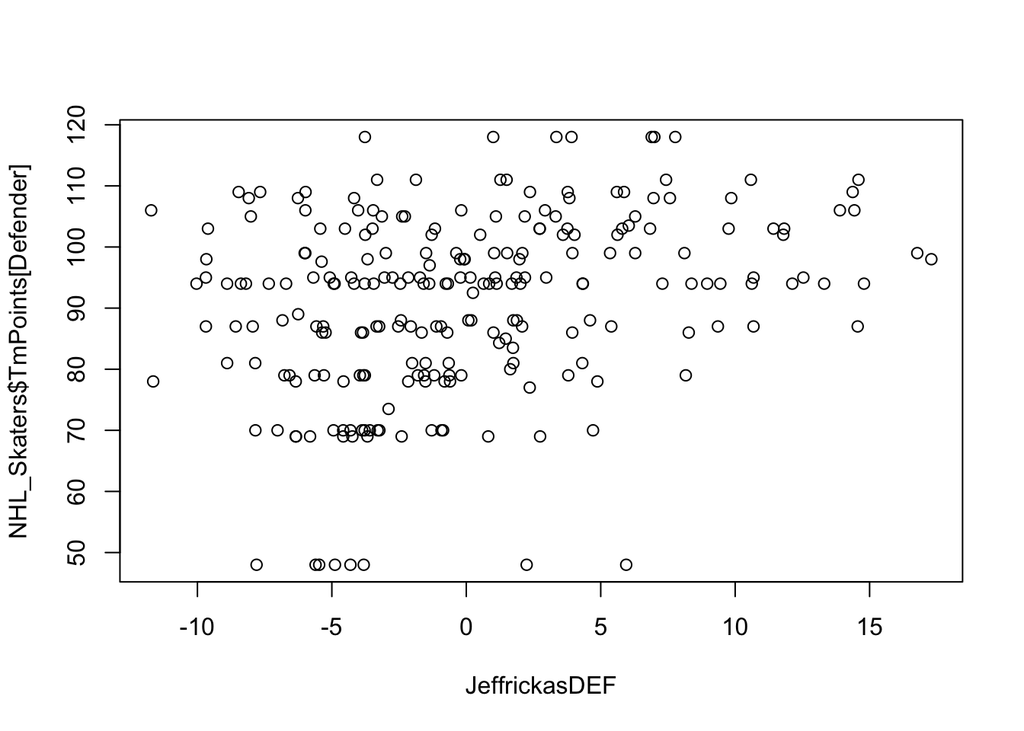

## Overall Jeffrickas Summary

[figure not shown]

[figure not shown]

Ryan Suter of the Minnesota Wild

## Correlation Plots

### Skaters

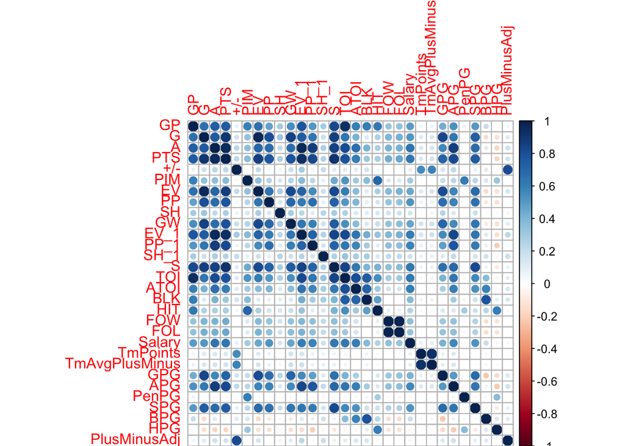

### Goalies

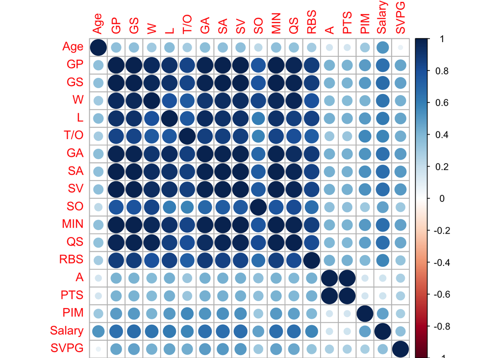